# Assessment of Exercise Activity Capability

Ruth Anne Lambert

Friday, February 12, 2016

### Data Partitioning

The original training dataset obtained from the website was sliced into training, testing, and validation sets with a partition of $64$%, $16$%, and $20$% respectively. Since the random forest method with boot strapping and the tree method with boosting take a considerable amount of time to compile using large datasets, a smaller training data set was created in order to create these models.

### Selecting Predictors

The activity dataset contains $160$ variables, $152$ of which are actual measurements from the electronic devices. Of these measurements, $100$ variables are only measured at new time “windows” and have values of “NA” during the remaining time intervals. These variables are not used in the analysis while the $52$ measurements with continuous data are used as the model predictors. A plot of the training data is shown in Figure 1 for two types of measurements. The figure shows clusters in the data according to the classe activity rating.

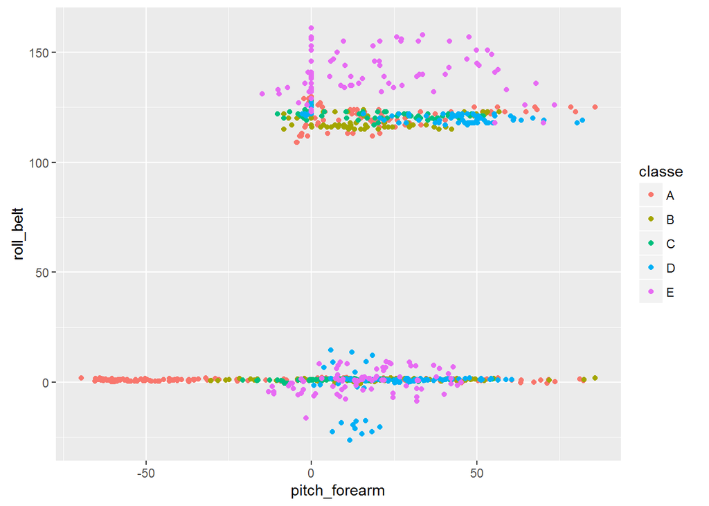

### Model Development

Since the outcome of the data is an activity “classifier”, and the data clearly exhibits clustering, prediction models that work well with clustering and classifiers are used. The three different models considered are:

- Random forest with bootstrapping
- Trees with boosting
- The Bayes method

The random tree and boosting methods are created using the smaller training data set while the Bayesian model is created using the larger training dataset. The accuracy of each model is determined using the full training set and is shown in Table 1. From the table it is evident that the random forest model with bootstrapping has the highest accuracy. The details of this random forest model are shown in Table 2.

```
##                rf     boost     bayes
## Accuracy 0.921258 0.8964172 0.7085987
```

```
## Random Forest
##
## 1008 samples
##   52 predictor
##    5 classes: 'A', 'B', 'C', 'D', 'E'
##
## No pre-processing
## Resampling: Bootstrapped (25 reps)
## Summary of sample sizes: 1008, 1008, 1008, 1008, 1008, 1008, ...
## Resampling results across tuning parameters:
##
##   mtry  Accuracy   Kappa      Accuracy SD  Kappa SD
##    2    0.8539455  0.8143551  0.01905725   0.02427279
##   27    0.8765694  0.8433042  0.01617431   0.02054117
##   52    0.8647782  0.8283487  0.01829201   0.02328359
##
## Accuracy was used to select the optimal model using  the largest value.
## The final value used for the model was mtry = 27.
```

### Model Selection and Validation

The three different models are applied to the test set, whose size is $16$% of the original data set. The purpose of applying the three prediction models to the test set, is to determine how they perform on data which was not used to create each model. The model with the highest accuracy is chosen for the next step, model validation. The accuracy of each model applied to the test set is shown in Table 3. The results show that the prediction accuracy of each model on the test set is slightly less than the accuracy using the training set. the random forest model achieves the highest accuracy of the three models and is selected as the final model.

```
##                rf     boost     bayes
## Accuracy 0.917782 0.8833652 0.7058636
```

The top four predictors of the random forest model are: 1) “roll_belt”, 2) “pitch_forearm”, 3) “magnet_dumbbell_z”, and 4) “magnet_dumbbell_y”. The random forest model is applied to the validation data set, which is $20$% of the original training data set and the results are shown in Table 4. A plot of the validation data set with each data point identified as correctly predicted and incorrectly predicted is shown in Figure 2.

```
##          final.model
## Accuracy   0.9156473
```

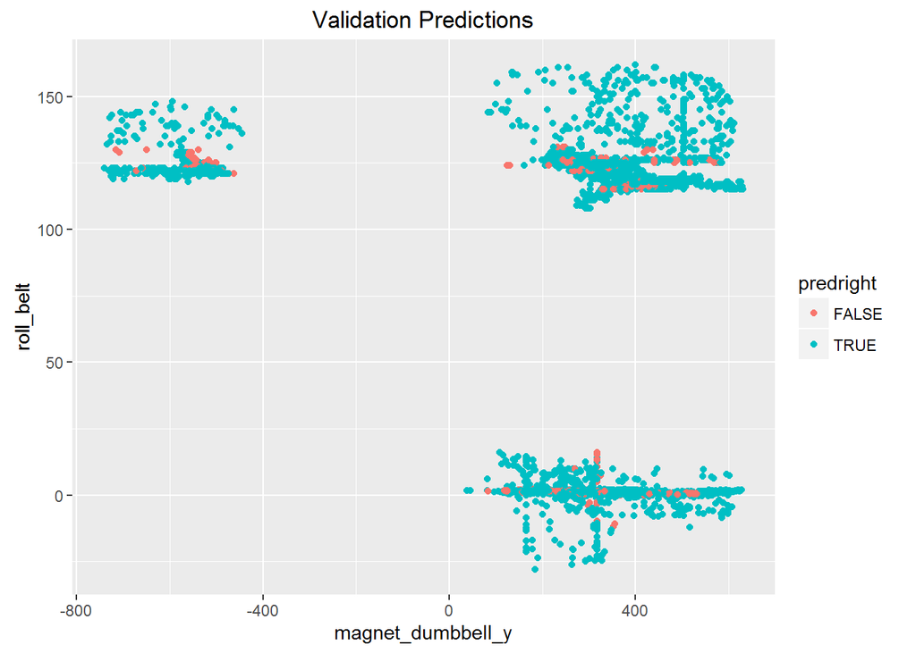

As a final test, the random forest model with bootstrapping outlined in this project will be used to identify the activity “classe” of $20$ measurements whose “classe” is unknown.